# Math Test

## Exploratory Data Analysis of the Temporal Direct Network Data

We are running exploratory data analyses of the French transfer networks. OUr data comes from the direct transfers of all France hospitals in 2024, all within a 7-day time frame aggregation within one year. Therefore, our first analysis would be a descriptive analyses of the basic network characteristics.

### Weekly Transfer Window Data

Let’s explore the direct transfers with 7-day (weekly) time window,starting for all year timespan.

```r
#Available here: https://drees2-sgsocialgouv.opendatasoft.com/explore/dataset/708_bases-statistiques-sae/information/
# CAPACT24 appears to refer to a capacity variable for full inpatient hospitalization, specifically the number of installed beds for hospitalisation complète (24 hours or more) in the relevant unit or activity table. The SAE variable list snippet for 2024 shows the label beginning with “Nombre de lits installés en hospitalisation complète…”, and the SAE documentation explains that the survey collects establishments’ capacities, activity, technical platforms, and staffing through thematic tables.

capact24 <- read_delim(here("Datasets", "CAPACT_PM_PNM","Bases CSV", "capact24.csv"),
                         delim = ";", escape_double = FALSE, trim_ws = TRUE,
                        locale = locale(encoding = "Latin1"))  #so it can read French vocals
#save capact into comma-separated CSV
write.csv(capact24, file = here("Datasets", "CAPACT24.csv"))

#Reading in Finess Georgaphical Coords data
finess_geo = read.csv(here("Datasets", "finessGeo_data.csv"))
head(finess_geo)
```

|  | finess | finessgeo | coordxet | coordyet |
| --- | --- | --- | --- | --- |
| 1 | 010780054 | 010000024 | 870262.2 | 6571541 |
| 2 | 010780062 | 010000032 | 908313.3 | 6520061 |
| 3 | 010780096 | 010000065 | 837272.3 | 6539470 |
| 4 | 010780112 | 010000081 | 935221.3 | 6584833 |
| 5 | 010780120 | 010000099 | 870118.2 | 6536469 |
| 6 | 010780138 | 010000107 | 849456.3 | 6594357 |

### Temporal Analysis of Trends by Weekly Time Window

Looking at the averages and summary statistics trend for day-to-day trends to see the ups and downs of the number of nodes, edges, transfers, and otehers

### Calculate the centrality measures statistics for the network data

## Network metrics definitions (weighted, directed hospital transfer network)

Let $G_t = (V_t, E_t)$ be the **directed, weighted** hospital transfer network for time window $t$.

- **Nodes** ($V_t$): hospitals (e.g., `finessGeo`)
- **Edges** ($E_t$): directed transfers from origin $\rightarrow$ target within the window
- **Edge weight** ($w_{ij,t}$): number of transfers from hospital $i$ to hospital $j$ in window $t$
- A “present” edge means $w_{ij,t} > 0$

## `n_nodes` — Number of active nodes

**Definition:**

$$n_{nodes}(t) = \left|V_t\right|$$

**Interpretation:** Number of hospitals that appear in the network during window $t$ as an origin and/or target with at least one transfer.

## `n_edges` — Number of directed edges

**Definition:**

$$n_{edges}(t) = \left|E_t\right|$$

where each directed pair $(i \rightarrow j)$ with $w_{ij,t} > 0$ counts as one edge.

**Interpretation:** Number of distinct **origin $\rightarrow$ destination** transfer connections observed in window $t$, regardless of volume.

## `total_transfers` — Total transfer volume (sum of weights)

**Definition:**

$$\mathrm{total\_transfers}(t) = \sum_{(i \rightarrow j)\in E_t} w_{ij,t}$$

**Interpretation:** Total number of patient transfers captured in window $t$ across all directed connections.

## `mean_weight` — Mean edge weight

**Definition:**

$$\mathrm{mean\_weight}(t) = \frac{1}{\left|E_t\right|}\sum_{(i
\rightarrow j)\in E_t} w_{ij,t}$$

**Interpretation:** Average number of transfers per observed directed connection in window $t$. Higher values imply that, on average, connections carry heavier transfer traffic.

## `median_weight` — Median edge weight

**Definition:**

The median of the set

$$\left\{ w_{ij,t} : (i \rightarrow j)\in E_t \right\}.$$

**Interpretation:** Typical transfer volume per observed directed connection, less sensitive to extreme high-volume routes than `mean_weight`.

## `density` — Directed network density (unweighted definition)

**Definition** (standard directed density without self-loops):

$$\mathrm{density}(t) =
\frac{\left|E_t\right|}{\left|V_t\right|\left(\left|V_t\right|-1\right)}$$

**Interpretation:** Proportion of all possible directed hospital-to-hospital connections that are observed (have at least one transfer) in window $t$.

- Values near 0: sparse network (few observed routes)
- Values near 1: highly connected network (many observed routes)

**Note:** This density is **about presence/absence of edges**, not transfer volume. Even in a weighted network, density is usually defined on the binary graph.

## Optional clarifications

- **Directed:** $(i \rightarrow j)$ is different from $(j \rightarrow i)$
- **Weighted:** edges carry magnitudes (number of transfers)
- **Active node:** a hospital with at least one incoming or outgoing transfer in that window
- **Edge counted once per pair per window:** multiple transfers on the same route contribute to the weight, not to additional edges

## Graphing all the Stats

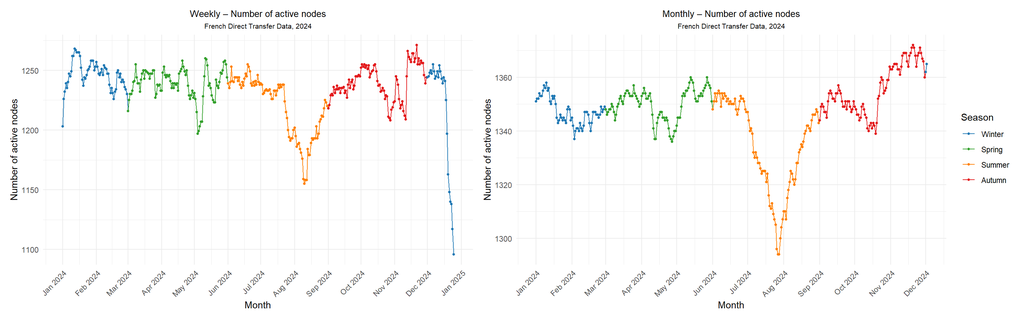

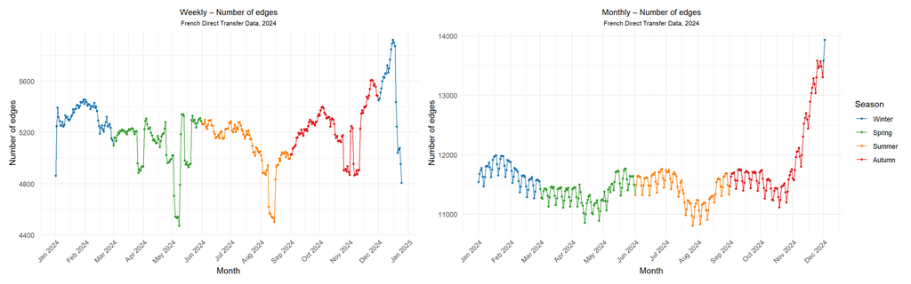

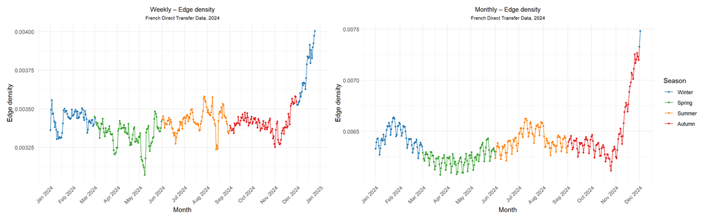

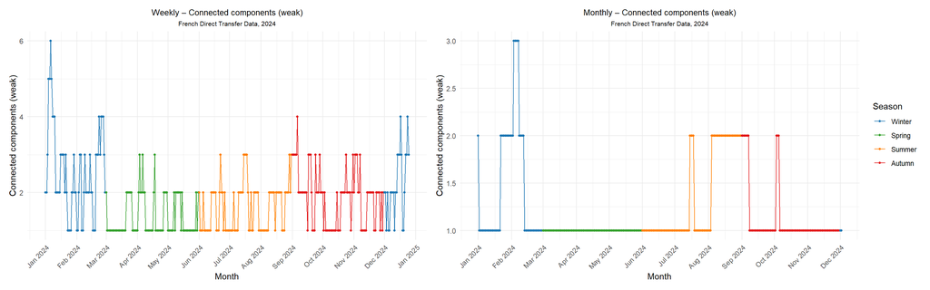

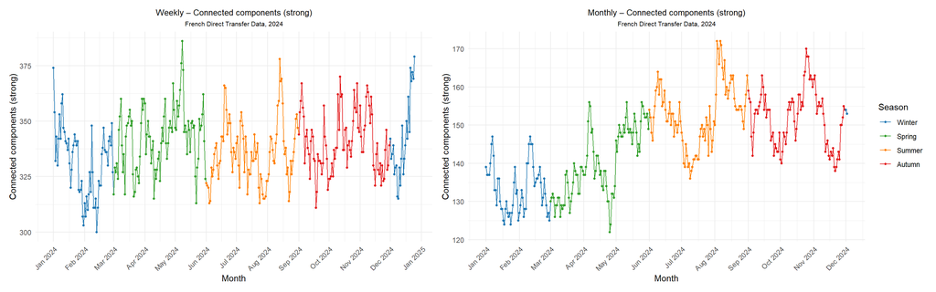

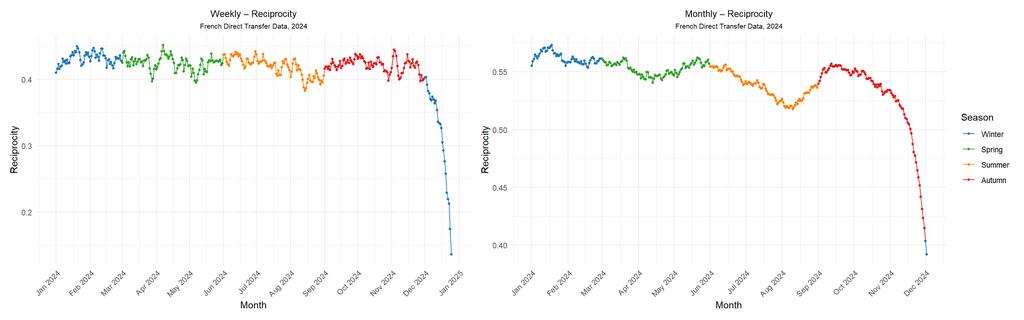

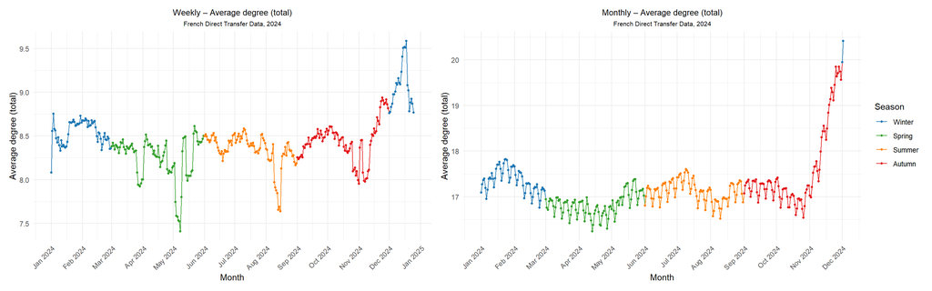

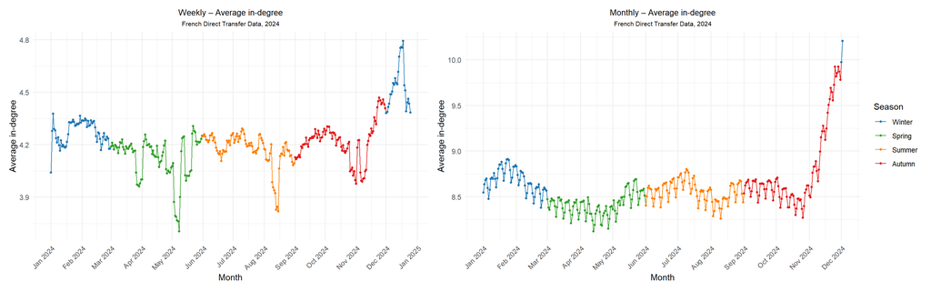

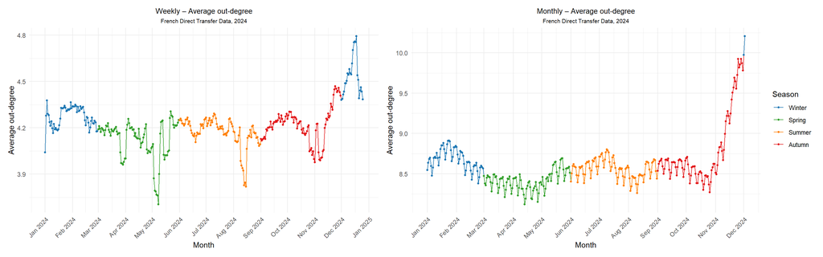

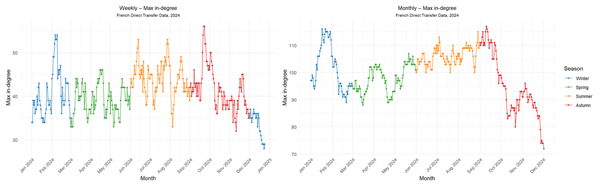

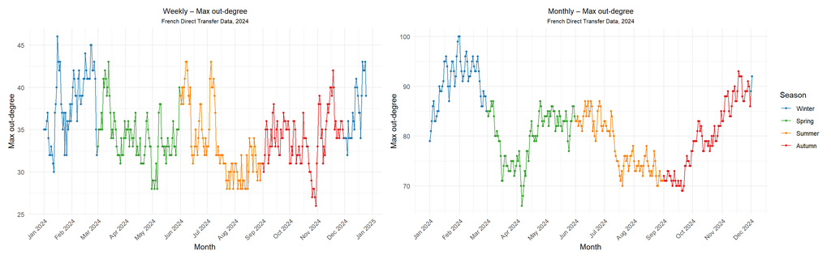

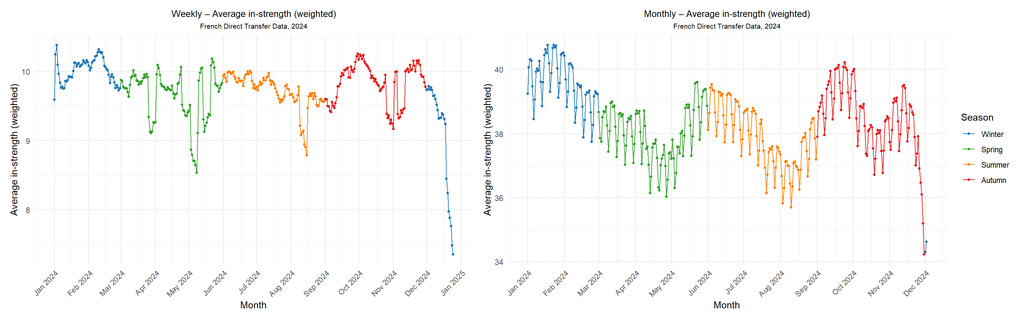

[12 more figures not shown]

[figure not shown]

```r
#install.packages("rnaturalearthhires", repos = "https://ropensci.r-universe.dev")
#install.packages("rnaturalearthdata")
library(rnaturalearth)
library(rnaturalearthdata)
france <- rnaturalearth::ne_states(country = "France", returnclass = "sf") %>%
  filter(!name %in% c("Guyane", "Martinique", "Guadeloupe", "La Réunion", "Mayotte"))

library(igraph)
library(ggplot2)
library(ggraph)
library(sf)
library(dplyr)
library(rnaturalearth)
library(RColorBrewer)

# ── 1. REGION CODE → LABEL (INSEE official names) ────────────────────────────
region_labels <- c(
  "11" = "Île-de-France",
  "24" = "Centre-Val de Loire",
  "27" = "Bourgogne-Franche-Comté",
  "28" = "Normandie",
  "32" = "Hauts-de-France",
  "44" = "Grand Est",
  "52" = "Pays de la Loire",
  "53" = "Bretagne",
  "75" = "Nouvelle-Aquitaine",
  "76" = "Occitanie",
  "84" = "Auvergne-Rhône-Alpes",
  "93" = "Provence-Alpes-Côte d'Azur",
  "94" = "Corse",
  "01" = "Guadeloupe",
  "02" = "Martinique",
  "03" = "Guyane",
  "04" = "La Réunion",
  "06" = "Mayotte"
)

# ── 2. BUILD NODE TABLE from CAPACT24 + finess_geo coords ────────────────────
# CAPACT24 has one row per hospital × discipline — deduplicate to one row per fi
capact_nodes <- capact24 %>%
  select(fi, rs, dep, reg) %>%
  distinct(fi, .keep_all = TRUE) %>%          # one row per FINESS code
  mutate(
    region = region_labels[as.character(reg)], # readable region name
    region = if_else(is.na(region), paste0("Région ", reg), region)
  )

# Join with geographic coordinates from finess_geo
# Adjust 'finessGeo' / 'x' / 'y' below to match your actual column names
nodes <- finess_geo %>%
  dplyr::rename(
    fi  = finessgeo,   # <- FINESS id column in finess_geo
    lon = coordxet,
    lat = coordyet
  ) %>%
  select(fi, lon, lat) %>%
  inner_join(capact_nodes, by = "fi")          # drops hospitals with no coords

# ── 3. AGGREGATE weekly → full-year cumulative edges ─────────────────────────
annual_edges <- weekly %>%
  group_by(finessGeo_origin, finessGeo_target) %>%
  summarise(total_weight = sum(weight, na.rm = TRUE), .groups = "drop")

# ── 4. JOIN edges with node attributes ───────────────────────────────────────
edges_geo <- annual_edges %>%
  inner_join(nodes, by = c("finessGeo_origin" = "fi")) %>%
  rename(lon_from = lon, lat_from = lat,
         region_from = region, name_from = rs) %>%
  inner_join(nodes, by = c("finessGeo_target" = "fi")) %>%
  rename(lon_to = lon, lat_to = lat,
         region_to = region, name_to = rs)

# ── 5. STRONG EDGES ONLY (top 10% by cumulative weight) ──────────────────────
strong_threshold <- quantile(edges_geo$total_weight, 0.90, na.rm = TRUE)
edges_strong     <- edges_geo %>% filter(total_weight >= strong_threshold)

active_ids   <- unique(c(edges_strong$finessGeo_origin,
                          edges_strong$finessGeo_target))
nodes_strong <- nodes %>% filter(fi %in% active_ids)

# ── 6. PROVINCE COLOUR PALETTE (metro France only) ───────────────────────────
metro_regions   <- region_labels[c("11","24","27","28","32","44",
                                    "52","53","75","76","84","93","94")]
province_levels <- sort(unique(nodes_strong$region))
n_prov          <- length(province_levels)
base_cols        <- brewer.pal(min(max(n_prov, 3), 12), "Paired")
if (n_prov > 12) base_cols <- colorRampPalette(base_cols)(n_prov)
province_colors  <- setNames(base_cols[seq_len(n_prov)], province_levels)

# ── 7A. VIZ 1 — NETWORK OVERLAID ON MAP OF FRANCE ────────────────────────────
france <- ne_states(country = "France", returnclass = "sf") %>%
  filter(!name %in% c("Guyane", "Martinique", "Guadeloupe",
                       "La Réunion", "Mayotte"))

p_map <- ggplot() +
  geom_sf(data = france,
          fill = "grey94", colour = "white", linewidth = 0.3) +
  geom_segment(
    data = edges_strong,
    aes(x = lon_from, y = lat_from,
        xend = lon_to,   yend = lat_to,
        colour    = region_from,
        alpha     = total_weight,
        linewidth = total_weight),
    show.legend = FALSE
  ) +
  scale_linewidth_continuous(range = c(0.15, 1.2)) +
  scale_alpha_continuous(range = c(0.2, 0.8)) +
  geom_point(
    data = nodes_strong,
    aes(x = lon, y = lat, colour = region),
    size = 1.8, alpha = 0.9
  ) +
  scale_colour_manual(values = province_colors, name = "Region") +
  coord_sf(xlim = c(-5.5, 10), ylim = c(41, 52)) +
  labs(
    title    = "Annual Cumulative Hospital Transfer Network — France 2024",
    subtitle = "Strong edges only (top 10% by volume). Nodes & edges coloured by sender region.",
    x = NULL, y = NULL
  ) +
  theme_void() +
  theme(
    plot.title    = element_text(hjust = 0.5, size = 14, face = "bold"),
    plot.subtitle = element_text(hjust = 0.5, size = 10),
    legend.position = "right"
  )

# ── 7B. VIZ 2 — ABSTRACT NETWORK GRAPH ───────────────────────────────────────
g <- igraph::graph_from_data_frame(
  d        = edges_strong %>%
               select(finessGeo_origin, finessGeo_target, total_weight,
                      region_from),
  directed = TRUE,
  vertices = nodes_strong %>% rename(name = fi)
)
V(g)$region <- nodes_strong$region[match(V(g)$name, nodes_strong$fi)]

layout_geo <- nodes_strong %>%
  arrange(match(fi, V(g)$name)) %>%
  select(lon, lat) %>%
  as.matrix()

p_graph <- ggraph(g, layout = layout_geo) +
  geom_edge_arc(
    aes(colour = region_from,
        width  = total_weight,
        alpha  = total_weight),
    arrow    = arrow(length = unit(2, "mm"), type = "closed"),
    end_cap  = circle(2, "mm"),
    strength = 0.15,
    show.legend = FALSE
  ) +
  scale_edge_width_continuous(range = c(0.15, 1.2)) +
  scale_edge_alpha_continuous(range = c(0.2,  0.8)) +
  scale_edge_colour_manual(values = province_colors) +
  geom_node_point(aes(colour = region), size = 2, alpha = 0.9) +
  scale_colour_manual(values = province_colors, name = "Region") +
  labs(
    title    = "Network Graph — Hospital Transfers France 2024",
    subtitle = "Strong edges only. Layout = geographic coordinates."
  ) +
  theme_graph(base_family = "sans") +
  theme(
    plot.title    = element_text(hjust = 0.5, size = 14, face = "bold"),
    plot.subtitle = element_text(hjust = 0.5, size = 10),
    legend.position = "right"
  )

# ── 8. PRINT ──────────────────────────────────────────────────────────────────
print(p_map)
```

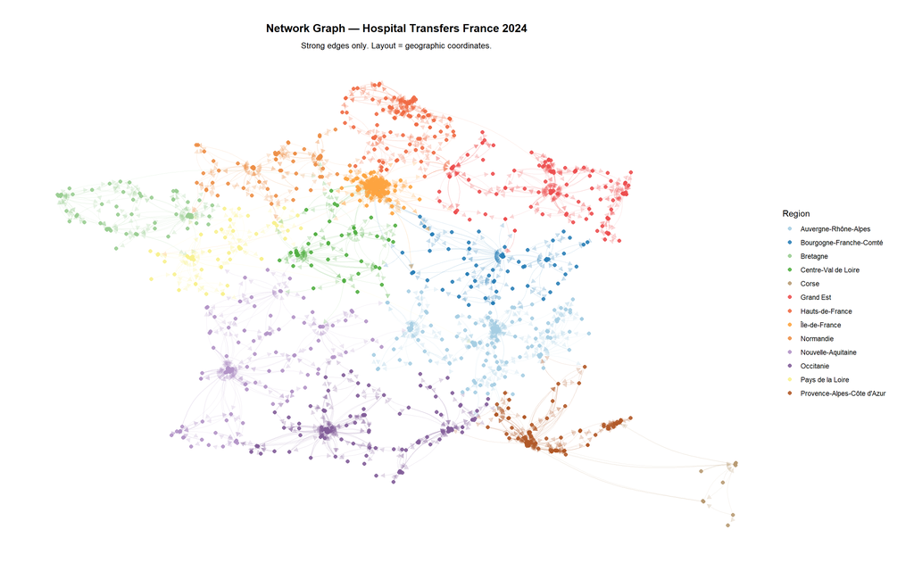

```r
print(p_graph)
```

```r
ggsave(here("Plots", "annual_network_map.jpeg"),   p_map,   width=16, height=10, dpi=300)
ggsave(here("Plots", "annual_network_graph.jpeg"), p_graph, width=16, height=10, dpi=300)
```